# Recommend System

### Importing libraries and data

```python
import numpy as np
import pandas as pd
import matplotlib.pyplot as plt
import seaborn as sns
%matplotlib inline
import plotly.offline as py
py.init_notebook_mode(connected=True)
import plotly.graph_objs as go
import plotly.tools as tls
import plotly.express as px
from wordcloud import WordCloud
import ast
import json
import warnings
warnings.filterwarnings('ignore')
```

```python
#Load datasets
df = pd.read_csv('C:/Users/GGPC/Desktop/tmdb_5000_movies.csv',engine='python')
df1 = pd.read_csv('C:/Users/GGPC/Desktop/tmdb_5000_credits.csv',engine='python')
```

```python
df.head()
```

|  | budget | genres | homepage | id | keywords | original_language | original_title | overview | popularity | production_companies | ... | title | vote_average | vote_count | Unnamed: 20 | Unnamed: 21 | Unnamed: 22 | Unnamed: 23 | Unnamed: 24 | Unnamed: 25 | Unnamed: 26 |
| --- | --- | --- | --- | --- | --- | --- | --- | --- | --- | --- | --- | --- | --- | --- | --- | --- | --- | --- | --- | --- | --- |
| 0 | 237000000 | [{"id": 28, "name": "Action"}, {"id": 12, "nam... | http://www.avatarmovie.com/ | 19995 | [{"id": 1463, "name": "culture clash"}, {"id":... | en | Avatar | In the 22nd century, a paraplegic Marine is di... | 150.437577 | [{"name": "Ingenious Film Partners", "id": 289... | ... | Avatar | 7.2 | 11800 | NaN | NaN | NaN | NaN | NaN | NaN | NaN |
| 1 | 300000000 | [{"id": 12, "name": "Adventure"}, {"id": 14, "... | http://disney.go.com/disneypictures/pirates/ | 285 | [{"id": 270, "name": "ocean"}, {"id": 726, "na... | en | Pirates of the Caribbean: At World's End | Captain Barbossa, long believed to be dead, ha... | 139.082615 | [{"name": "Walt Disney Pictures", "id": 2}, {"... | ... | Pirates of the Caribbean: At World's End | 6.9 | 4500 | NaN | NaN | NaN | NaN | NaN | NaN | NaN |
| 2 | 245000000 | [{"id": 28, "name": "Action"}, {"id": 12, "nam... | http://www.sonypictures.com/movies/spectre/ | 206647 | [{"id": 470, "name": "spy"}, {"id": 818, "name... | en | Spectre | A cryptic message from Bond鈥檚 past sends him o... | 107.376788 | [{"name": "Columbia Pictures", "id": 5}, {"nam... | ... | Spectre | 6.3 | 4466 | NaN | NaN | NaN | NaN | NaN | NaN | NaN |
| 3 | 250000000 | [{"id": 28, "name": "Action"}, {"id": 80, "nam... | http://www.thedarkknightrises.com/ | 49026 | [{"id": 849, "name": "dc comics"}, {"id": 853,... | en | The Dark Knight Rises | Following the death of District Attorney Harve... | 112.31295 | [{"name": "Legendary Pictures", "id": 923}, {"... | ... | The Dark Knight Rises | 7.6 | 9106 | NaN | NaN | NaN | NaN | NaN | NaN | NaN |
| 4 | 260000000 | [{"id": 28, "name": "Action"}, {"id": 12, "nam... | http://movies.disney.com/john-carter | 49529 | [{"id": 818, "name": "based on novel"}, {"id":... | en | John Carter | John Carter is a war-weary, former military ca... | 43.926995 | [{"name": "Walt Disney Pictures", "id": 2}] | ... | John Carter | 6.1 | 2124 | NaN | NaN | NaN | NaN | NaN | NaN | NaN |

5 rows × 27 columns

### 1.Data Preprocessing

```python
#We need convert data type for some columns later
df.info()
```

```
<class 'pandas.core.frame.DataFrame'>
RangeIndex: 4802 entries, 0 to 4801
Data columns (total 27 columns):
 #   Column                Non-Null Count  Dtype
---  ------                --------------  -----
 0   budget                4802 non-null   int64
 1   genres                4802 non-null   object
 2   homepage              1712 non-null   object
 3   id                    4802 non-null   int64
 4   keywords              4802 non-null   object
 5   original_language     4802 non-null   object
 6   original_title        4802 non-null   object
 7   overview              4799 non-null   object
 8   popularity            4802 non-null   object
 9   production_companies  4802 non-null   object
```

[output cut: 19 more lines]

```python
df1.head()
```

|  | movie_id | title | cast | crew |
| --- | --- | --- | --- | --- |
| 0 | 19995 | Avatar | [{"cast_id": 242, "character": "Jake Sully", "... | [{"credit_id": "52fe48009251416c750aca23", "de... |
| 1 | 285 | Pirates of the Caribbean: At World's End | [{"cast_id": 4, "character": "Captain Jack Spa... | [{"credit_id": "52fe4232c3a36847f800b579", "de... |
| 2 | 206647 | Spectre | [{"cast_id": 1, "character": "James Bond", "cr... | [{"credit_id": "54805967c3a36829b5002c41", "de... |
| 3 | 49026 | The Dark Knight Rises | [{"cast_id": 2, "character": "Bruce Wayne / Ba... | [{"credit_id": "52fe4781c3a36847f81398c3", "de... |
| 4 | 49529 | John Carter | [{"cast_id": 5, "character": "John Carter", "c... | [{"credit_id": "52fe479ac3a36847f813eaa3", "de... |

```python
#Rename columns
df1.columns=['id','title','cast','crew']
```

```python
df.shape
```

```
(4802, 27)
```

```python
df1.shape
```

```
(4803, 4)
```

```python
#Merge datasets
df2 = df.merge(df1, on='id')
df2.head()
```

|  | budget | genres | homepage | id | keywords | original_language | original_title | overview | popularity | production_companies | ... | Unnamed: 20 | Unnamed: 21 | Unnamed: 22 | Unnamed: 23 | Unnamed: 24 | Unnamed: 25 | Unnamed: 26 | title_y | cast | crew |
| --- | --- | --- | --- | --- | --- | --- | --- | --- | --- | --- | --- | --- | --- | --- | --- | --- | --- | --- | --- | --- | --- |
| 0 | 237000000 | [{"id": 28, "name": "Action"}, {"id": 12, "nam... | http://www.avatarmovie.com/ | 19995 | [{"id": 1463, "name": "culture clash"}, {"id":... | en | Avatar | In the 22nd century, a paraplegic Marine is di... | 150.437577 | [{"name": "Ingenious Film Partners", "id": 289... | ... | NaN | NaN | NaN | NaN | NaN | NaN | NaN | Avatar | [{"cast_id": 242, "character": "Jake Sully", "... | [{"credit_id": "52fe48009251416c750aca23", "de... |
| 1 | 300000000 | [{"id": 12, "name": "Adventure"}, {"id": 14, "... | http://disney.go.com/disneypictures/pirates/ | 285 | [{"id": 270, "name": "ocean"}, {"id": 726, "na... | en | Pirates of the Caribbean: At World's End | Captain Barbossa, long believed to be dead, ha... | 139.082615 | [{"name": "Walt Disney Pictures", "id": 2}, {"... | ... | NaN | NaN | NaN | NaN | NaN | NaN | NaN | Pirates of the Caribbean: At World's End | [{"cast_id": 4, "character": "Captain Jack Spa... | [{"credit_id": "52fe4232c3a36847f800b579", "de... |
| 2 | 245000000 | [{"id": 28, "name": "Action"}, {"id": 12, "nam... | http://www.sonypictures.com/movies/spectre/ | 206647 | [{"id": 470, "name": "spy"}, {"id": 818, "name... | en | Spectre | A cryptic message from Bond鈥檚 past sends him o... | 107.376788 | [{"name": "Columbia Pictures", "id": 5}, {"nam... | ... | NaN | NaN | NaN | NaN | NaN | NaN | NaN | Spectre | [{"cast_id": 1, "character": "James Bond", "cr... | [{"credit_id": "54805967c3a36829b5002c41", "de... |
| 3 | 250000000 | [{"id": 28, "name": "Action"}, {"id": 80, "nam... | http://www.thedarkknightrises.com/ | 49026 | [{"id": 849, "name": "dc comics"}, {"id": 853,... | en | The Dark Knight Rises | Following the death of District Attorney Harve... | 112.31295 | [{"name": "Legendary Pictures", "id": 923}, {"... | ... | NaN | NaN | NaN | NaN | NaN | NaN | NaN | The Dark Knight Rises | [{"cast_id": 2, "character": "Bruce Wayne / Ba... | [{"credit_id": "52fe4781c3a36847f81398c3", "de... |
| 4 | 260000000 | [{"id": 28, "name": "Action"}, {"id": 12, "nam... | http://movies.disney.com/john-carter | 49529 | [{"id": 818, "name": "based on novel"}, {"id":... | en | John Carter | John Carter is a war-weary, former military ca... | 43.926995 | [{"name": "Walt Disney Pictures", "id": 2}] | ... | NaN | NaN | NaN | NaN | NaN | NaN | NaN | John Carter | [{"cast_id": 5, "character": "John Carter", "c... | [{"credit_id": "52fe479ac3a36847f813eaa3", "de... |

5 rows × 30 columns

```python
#Drop blank columns
df2.drop(['Unnamed: 20','Unnamed: 21','Unnamed: 22','Unnamed: 23','Unnamed: 24','Unnamed: 25','Unnamed: 26'],axis=1,inplace=True)
df2.head()
```

|  | budget | genres | homepage | id | keywords | original_language | original_title | overview | popularity | production_companies | ... | runtime | spoken_languages | status | tagline | title_x | vote_average | vote_count | title_y | cast | crew |
| --- | --- | --- | --- | --- | --- | --- | --- | --- | --- | --- | --- | --- | --- | --- | --- | --- | --- | --- | --- | --- | --- |
| 0 | 237000000 | [{"id": 28, "name": "Action"}, {"id": 12, "nam... | http://www.avatarmovie.com/ | 19995 | [{"id": 1463, "name": "culture clash"}, {"id":... | en | Avatar | In the 22nd century, a paraplegic Marine is di... | 150.437577 | [{"name": "Ingenious Film Partners", "id": 289... | ... | 162 | [{"iso_639_1": "en", "name": "English"}, {"iso... | Released | Enter the World of Pandora. | Avatar | 7.2 | 11800 | Avatar | [{"cast_id": 242, "character": "Jake Sully", "... | [{"credit_id": "52fe48009251416c750aca23", "de... |
| 1 | 300000000 | [{"id": 12, "name": "Adventure"}, {"id": 14, "... | http://disney.go.com/disneypictures/pirates/ | 285 | [{"id": 270, "name": "ocean"}, {"id": 726, "na... | en | Pirates of the Caribbean: At World's End | Captain Barbossa, long believed to be dead, ha... | 139.082615 | [{"name": "Walt Disney Pictures", "id": 2}, {"... | ... | 169 | [{"iso_639_1": "en", "name": "English"}] | Released | At the end of the world, the adventure begins. | Pirates of the Caribbean: At World's End | 6.9 | 4500 | Pirates of the Caribbean: At World's End | [{"cast_id": 4, "character": "Captain Jack Spa... | [{"credit_id": "52fe4232c3a36847f800b579", "de... |
| 2 | 245000000 | [{"id": 28, "name": "Action"}, {"id": 12, "nam... | http://www.sonypictures.com/movies/spectre/ | 206647 | [{"id": 470, "name": "spy"}, {"id": 818, "name... | en | Spectre | A cryptic message from Bond鈥檚 past sends him o... | 107.376788 | [{"name": "Columbia Pictures", "id": 5}, {"nam... | ... | 148 | [{"iso_639_1": "fr", "name": "Fran\u00e7ais"},... | Released | A Plan No One Escapes | Spectre | 6.3 | 4466 | Spectre | [{"cast_id": 1, "character": "James Bond", "cr... | [{"credit_id": "54805967c3a36829b5002c41", "de... |
| 3 | 250000000 | [{"id": 28, "name": "Action"}, {"id": 80, "nam... | http://www.thedarkknightrises.com/ | 49026 | [{"id": 849, "name": "dc comics"}, {"id": 853,... | en | The Dark Knight Rises | Following the death of District Attorney Harve... | 112.31295 | [{"name": "Legendary Pictures", "id": 923}, {"... | ... | 165 | [{"iso_639_1": "en", "name": "English"}] | Released | The Legend Ends | The Dark Knight Rises | 7.6 | 9106 | The Dark Knight Rises | [{"cast_id": 2, "character": "Bruce Wayne / Ba... | [{"credit_id": "52fe4781c3a36847f81398c3", "de... |
| 4 | 260000000 | [{"id": 28, "name": "Action"}, {"id": 12, "nam... | http://movies.disney.com/john-carter | 49529 | [{"id": 818, "name": "based on novel"}, {"id":... | en | John Carter | John Carter is a war-weary, former military ca... | 43.926995 | [{"name": "Walt Disney Pictures", "id": 2}] | ... | 132 | [{"iso_639_1": "en", "name": "English"}] | Released | Lost in our world, found in another. | John Carter | 6.1 | 2124 | John Carter | [{"cast_id": 5, "character": "John Carter", "c... | [{"credit_id": "52fe479ac3a36847f813eaa3", "de... |

5 rows × 23 columns

### As some columns are Json format, it is not convenient for data analysis, we will parse this format.

```python
#Parsing Json
from ast import literal_eval

features = ['cast', 'crew', 'keywords', 'genres']
for feature in features:
    df2[feature] = df2[feature].apply(literal_eval)
```

```python
# Get the director's name from the crew feature. If director is not listed, return NaN
def get_director(x):
    for i in x:
        if i['job'] == 'Director':
            return i['name']
    return np.nan
```

```python
# Returns the list top 3 elements or entire list; whichever is more.
def get_list(x):
    if isinstance(x, list):
        names = [i['name'] for i in x]
        #Check if more than 3 elements exist. If yes, return only first three. If no, return entire list.
        if len(names) > 5:
            names = names[:5]
        return names

    #Return empty list in case of missing/malformed data
    return []
```

```python
# Define new director, cast, genres and keywords features that are in a suitable form.
df2['director'] = df2['crew'].apply(get_director)

features = ['cast', 'keywords', 'genres']
for feature in features:
    df2[feature] = df2[feature].apply(get_list)
```

```python
df2.head(2)
```

|  | budget | genres | homepage | id | keywords | original_language | original_title | overview | popularity | production_companies | ... | spoken_languages | status | tagline | title_x | vote_average | vote_count | title_y | cast | crew | director |
| --- | --- | --- | --- | --- | --- | --- | --- | --- | --- | --- | --- | --- | --- | --- | --- | --- | --- | --- | --- | --- | --- |
| 0 | 237000000 | [Action, Adventure, Fantasy, Science Fiction] | http://www.avatarmovie.com/ | 19995 | [culture clash, future, space war, space colon... | en | Avatar | In the 22nd century, a paraplegic Marine is di... | 150.437577 | [{"name": "Ingenious Film Partners", "id": 289... | ... | [{"iso_639_1": "en", "name": "English"}, {"iso... | Released | Enter the World of Pandora. | Avatar | 7.2 | 11800 | Avatar | [Sam Worthington, Zoe Saldana, Sigourney Weave... | [{'credit_id': '52fe48009251416c750aca23', 'de... | James Cameron |
| 1 | 300000000 | [Adventure, Fantasy, Action] | http://disney.go.com/disneypictures/pirates/ | 285 | [ocean, drug abuse, exotic island, east india ... | en | Pirates of the Caribbean: At World's End | Captain Barbossa, long believed to be dead, ha... | 139.082615 | [{"name": "Walt Disney Pictures", "id": 2}, {"... | ... | [{"iso_639_1": "en", "name": "English"}] | Released | At the end of the world, the adventure begins. | Pirates of the Caribbean: At World's End | 6.9 | 4500 | Pirates of the Caribbean: At World's End | [Johnny Depp, Orlando Bloom, Keira Knightley, ... | [{'credit_id': '52fe4232c3a36847f800b579', 'de... | Gore Verbinski |

2 rows × 24 columns

### 2. Visualization

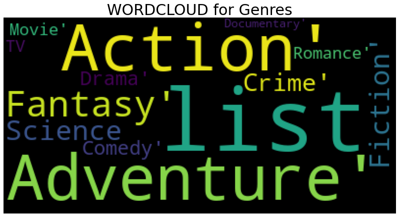

```python
#Generate wordcloud for genres
plt.figure(figsize=(14, 10))
text = df2['genres'].values

wordcloud = WordCloud().generate(str(text))

plt.imshow(wordcloud)
plt.axis("off")
plt.title('WORDCLOUD for Genres',fontsize=30)
plt.show()
```

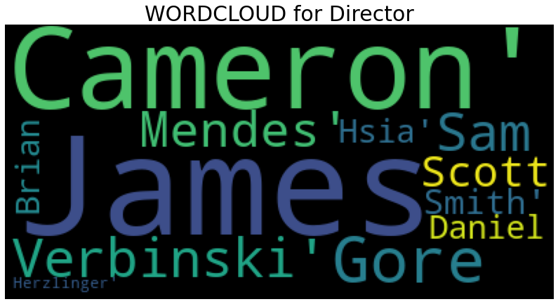

```python
plt.figure(figsize=(14, 10))
text = df2['director'].values

wordcloud = WordCloud().generate(str(text))

plt.imshow(wordcloud)
plt.axis("off")
plt.title('WORDCLOUD for Director',fontsize=30)
plt.show()
```

```python
#Check missing values for release date
df2.loc[df2['release_date'].isnull()==True]
```

|  | budget | genres | homepage | id | keywords | original_language | original_title | overview | popularity | production_companies | ... | spoken_languages | status | tagline | title_x | vote_average | vote_count | title_y | cast | crew | director |
| --- | --- | --- | --- | --- | --- | --- | --- | --- | --- | --- | --- | --- | --- | --- | --- | --- | --- | --- | --- | --- | --- |
| 4552 | 0 | [] | NaN | 380097 | [] | en | America Is Still the Place | 1971 post civil rights San Francisco seemed li... | 0 | [] | ... | [] | Released | NaN | America Is Still the Place | 0 | 0 | America Is Still the Place | [] | [] | NaN |

1 rows × 24 columns

```python
df2['release_date']=df2['release_date'].fillna('2014-06-01')
```

```python
#Check missing values for run time
df2.loc[df2['runtime'].isnull()==True]
```

|  | budget | genres | homepage | id | keywords | original_language | original_title | overview | popularity | production_companies | ... | spoken_languages | status | tagline | title_x | vote_average | vote_count | title_y | cast | crew | director |
| --- | --- | --- | --- | --- | --- | --- | --- | --- | --- | --- | --- | --- | --- | --- | --- | --- | --- | --- | --- | --- | --- |
| 2656 | 15000000 | [Drama] | NaN | 370980 | [pope, biography] | it | Chiamatemi Francesco - Il Papa della gente | NaN | 0.738646 | [{"name": "Taodue Film", "id": 45724}] | ... | [{"iso_639_1": "es", "name": "Espa\u00f1ol"}] | Released | NaN | Chiamatemi Francesco - Il Papa della gente | 7.3 | 12 | Chiamatemi Francesco - Il Papa della gente | [Rodrigo de la Serna, Sergio Hernández, Àlex B... | [{'credit_id': '5660019ac3a36875f100252b', 'de... | Daniele Luchetti |
| 4139 | 2 | [Documentary] | NaN | 459488 | [music, actors, legendary perfomer, classic ho... | en | To Be Frank, Sinatra at 100 | NaN | 0.050625 | [{"name": "Eyeline Entertainment", "id": 60343}] | ... | [] | Released | NaN | To Be Frank, Sinatra at 100 | 0 | 0 | To Be Frank, Sinatra at 100 | [Tony Oppedisano] | [{'credit_id': '592b25e4c3a368783e065a2f', 'de... | Simon Napier-Bell |

2 rows × 24 columns

```python
df2['runtime'] = df2['runtime'].fillna(94, limit=1)
df2['runtime'] = df2['runtime'].fillna(240, limit=1)
```

```python
df2['release_date'] = pd.to_datetime(df2['release_date'], format='%Y-%m-%d', errors='coerce').dt.year
```

```python
rename_dict = {'release_date':'year','cast':'actor'}
df2.rename(columns=rename_dict, inplace=True)
```

```python
df2.head()
```

|  | budget | genres | homepage | id | keywords | original_language | original_title | overview | popularity | production_companies | ... | spoken_languages | status | tagline | title_x | vote_average | vote_count | title_y | actor | crew | director |
| --- | --- | --- | --- | --- | --- | --- | --- | --- | --- | --- | --- | --- | --- | --- | --- | --- | --- | --- | --- | --- | --- |
| 0 | 237000000 | [Action, Adventure, Fantasy, Science Fiction] | http://www.avatarmovie.com/ | 19995 | [culture clash, future, space war, space colon... | en | Avatar | In the 22nd century, a paraplegic Marine is di... | 150.437577 | [{"name": "Ingenious Film Partners", "id": 289... | ... | [{"iso_639_1": "en", "name": "English"}, {"iso... | Released | Enter the World of Pandora. | Avatar | 7.2 | 11800 | Avatar | [Sam Worthington, Zoe Saldana, Sigourney Weave... | [{'credit_id': '52fe48009251416c750aca23', 'de... | James Cameron |
| 1 | 300000000 | [Adventure, Fantasy, Action] | http://disney.go.com/disneypictures/pirates/ | 285 | [ocean, drug abuse, exotic island, east india ... | en | Pirates of the Caribbean: At World's End | Captain Barbossa, long believed to be dead, ha... | 139.082615 | [{"name": "Walt Disney Pictures", "id": 2}, {"... | ... | [{"iso_639_1": "en", "name": "English"}] | Released | At the end of the world, the adventure begins. | Pirates of the Caribbean: At World's End | 6.9 | 4500 | Pirates of the Caribbean: At World's End | [Johnny Depp, Orlando Bloom, Keira Knightley, ... | [{'credit_id': '52fe4232c3a36847f800b579', 'de... | Gore Verbinski |
| 2 | 245000000 | [Action, Adventure, Crime] | http://www.sonypictures.com/movies/spectre/ | 206647 | [spy, based on novel, secret agent, sequel, mi6] | en | Spectre | A cryptic message from Bond鈥檚 past sends him o... | 107.376788 | [{"name": "Columbia Pictures", "id": 5}, {"nam... | ... | [{"iso_639_1": "fr", "name": "Fran\u00e7ais"},... | Released | A Plan No One Escapes | Spectre | 6.3 | 4466 | Spectre | [Daniel Craig, Christoph Waltz, Léa Seydoux, R... | [{'credit_id': '54805967c3a36829b5002c41', 'de... | Sam Mendes |
| 3 | 250000000 | [Action, Crime, Drama, Thriller] | http://www.thedarkknightrises.com/ | 49026 | [dc comics, crime fighter, terrorist, secret i... | en | The Dark Knight Rises | Following the death of District Attorney Harve... | 112.31295 | [{"name": "Legendary Pictures", "id": 923}, {"... | ... | [{"iso_639_1": "en", "name": "English"}] | Released | The Legend Ends | The Dark Knight Rises | 7.6 | 9106 | The Dark Knight Rises | [Christian Bale, Michael Caine, Gary Oldman, A... | [{'credit_id': '52fe4781c3a36847f81398c3', 'de... | Christopher Nolan |
| 4 | 260000000 | [Action, Adventure, Science Fiction] | http://movies.disney.com/john-carter | 49529 | [based on novel, mars, medallion, space travel... | en | John Carter | John Carter is a war-weary, former military ca... | 43.926995 | [{"name": "Walt Disney Pictures", "id": 2}] | ... | [{"iso_639_1": "en", "name": "English"}] | Released | Lost in our world, found in another. | John Carter | 6.1 | 2124 | John Carter | [Taylor Kitsch, Lynn Collins, Samantha Morton,... | [{'credit_id': '52fe479ac3a36847f813eaa3', 'de... | Andrew Stanton |

5 rows × 24 columns

```python
#Analyze genres changes over time
genres = df2.groupby('year')['genres'].count()

fig = go.Figure()
fig.add_trace(go.Scatter(x=genres.index, y=genres.values,
                    mode='lines+markers',marker_color='blue',name='genres'))


fig.update_layout(title_text='Movie Statistics')
fig.add_annotation(
            x=2009,
            y=genres.values.max(),
            text="Peak")

fig.show()
```

[interactive chart not shown]

### The film industry has been in an explosive stage since the 1990s.

```python
#Convert revenue into int
df2['revenue'] = pd.to_numeric(df2['revenue'], errors='coerce').fillna(0)
df2['revenue'] = df2['revenue'].astype(np.int64)
```

```python
#Create profit column
df2['profit'] = df2['revenue']-df2['budget']
```

```python
df2['profit_rate'] = df2['profit'] / df2['budget']
df2.head()
```

|  | budget | genres | homepage | id | keywords | original_language | original_title | overview | popularity | production_companies | ... | tagline | title_x | vote_average | vote_count | title_y | actor | crew | director | profit | profit_rate |
| --- | --- | --- | --- | --- | --- | --- | --- | --- | --- | --- | --- | --- | --- | --- | --- | --- | --- | --- | --- | --- | --- |
| 0 | 237000000 | [Action, Adventure, Fantasy, Science Fiction] | http://www.avatarmovie.com/ | 19995 | [culture clash, future, space war, space colon... | en | Avatar | In the 22nd century, a paraplegic Marine is di... | 150.437577 | [{"name": "Ingenious Film Partners", "id": 289... | ... | Enter the World of Pandora. | Avatar | 7.2 | 11800 | Avatar | [Sam Worthington, Zoe Saldana, Sigourney Weave... | [{'credit_id': '52fe48009251416c750aca23', 'de... | James Cameron | 2550965087 | 10.763566 |
| 1 | 300000000 | [Adventure, Fantasy, Action] | http://disney.go.com/disneypictures/pirates/ | 285 | [ocean, drug abuse, exotic island, east india ... | en | Pirates of the Caribbean: At World's End | Captain Barbossa, long believed to be dead, ha... | 139.082615 | [{"name": "Walt Disney Pictures", "id": 2}, {"... | ... | At the end of the world, the adventure begins. | Pirates of the Caribbean: At World's End | 6.9 | 4500 | Pirates of the Caribbean: At World's End | [Johnny Depp, Orlando Bloom, Keira Knightley, ... | [{'credit_id': '52fe4232c3a36847f800b579', 'de... | Gore Verbinski | 661000000 | 2.203333 |
| 2 | 245000000 | [Action, Adventure, Crime] | http://www.sonypictures.com/movies/spectre/ | 206647 | [spy, based on novel, secret agent, sequel, mi6] | en | Spectre | A cryptic message from Bond鈥檚 past sends him o... | 107.376788 | [{"name": "Columbia Pictures", "id": 5}, {"nam... | ... | A Plan No One Escapes | Spectre | 6.3 | 4466 | Spectre | [Daniel Craig, Christoph Waltz, Léa Seydoux, R... | [{'credit_id': '54805967c3a36829b5002c41', 'de... | Sam Mendes | 635674609 | 2.594590 |
| 3 | 250000000 | [Action, Crime, Drama, Thriller] | http://www.thedarkknightrises.com/ | 49026 | [dc comics, crime fighter, terrorist, secret i... | en | The Dark Knight Rises | Following the death of District Attorney Harve... | 112.31295 | [{"name": "Legendary Pictures", "id": 923}, {"... | ... | The Legend Ends | The Dark Knight Rises | 7.6 | 9106 | The Dark Knight Rises | [Christian Bale, Michael Caine, Gary Oldman, A... | [{'credit_id': '52fe4781c3a36847f81398c3', 'de... | Christopher Nolan | 834939099 | 3.339756 |
| 4 | 260000000 | [Action, Adventure, Science Fiction] | http://movies.disney.com/john-carter | 49529 | [based on novel, mars, medallion, space travel... | en | John Carter | John Carter is a war-weary, former military ca... | 43.926995 | [{"name": "Walt Disney Pictures", "id": 2}] | ... | Lost in our world, found in another. | John Carter | 6.1 | 2124 | John Carter | [Taylor Kitsch, Lynn Collins, Samantha Morton,... | [{'credit_id': '52fe479ac3a36847f813eaa3', 'de... | Andrew Stanton | 24139100 | 0.092843 |

5 rows × 26 columns

```python
#Analyze profit changes over time
revenues = df2.groupby('year')['revenue'].sum()
budgets = df2.groupby('year')['budget'].sum()
profits = df2.groupby('year')['profit'].sum()

fig = go.Figure()
fig.add_trace(go.Scatter(x=revenues.index, y=revenues.values,
                    mode='lines',marker_color='blue',name='Revenues'))

fig.add_trace(go.Scatter(x=budgets.index, y=budgets.values,
                    mode='lines',marker_color='red',name='Budgets'))

fig.add_trace(go.Scatter(x=profits.index, y=profits.values,
                    mode='lines',marker_color='green',name='Profits'))

fig.update_layout(title_text='Profit Statistics')
fig.add_annotation(
            x=2012,
            y=revenues.values.max(),
            text="Peak")

fig.show()
```

[interactive chart not shown]

```python
def get_most_10(data, column):
    temp_data = data.apply(lambda x: pd.Series(x[column], dtype='object'),axis=1).stack().reset_index(level=1, drop=True)
    a = temp_data.value_counts().reset_index()
    a.rename(columns={0: 'Value'})
    fig = px.bar(a.iloc[:10][::-1], x=0, y='index', orientation='h', title="Top 10 {}".format(column),color_discrete_sequence=px.colors.qualitative.G10)
    fig.show()
```

```python
most_profit_movies = df2.sort_values(by="profit", ascending=False).head(200)
get_most_10( most_profit_movies, 'genres')
```

[interactive chart not shown]

### The top three highest-grossing movie styles were adventure, action and family.

```python
#Convert into numeric data type
df2['popularity'] = pd.to_numeric(df2['popularity'], errors='coerce').fillna(0)
df2['vote_average'] = pd.to_numeric(df2['vote_average'], errors='coerce').fillna(0)
```

```python
#Correlation between popularity and average vote
df2['popularity'].corr(df2['vote_average'])
```

```
0.00036199745111375624
```

### The results showed a very low correlation between popularity and average voting.

```python
df2[['popularity','vote_average','budget','revenue']].corr()
```

|  | popularity | vote_average | budget | revenue |
| --- | --- | --- | --- | --- |
| popularity | 1.000000 | 0.000362 | 0.503779 | 0.644919 |
| vote_average | 0.000362 | 1.000000 | 0.008284 | -0.000204 |
| budget | 0.503779 | 0.008284 | 1.000000 | 0.730033 |
| revenue | 0.644919 | -0.000204 | 0.730033 | 1.000000 |

### The most important factors affecting the box office are budget and popularity.

```python
get_most_10(df2, 'genres')
```

[interactive chart not shown]

### The largest number of films were in the drama, comedy and thriller categories.

```python
get_most_10(df2, 'keywords')
```

[interactive chart not shown]

### The top keywords were independent films, original films and female directors.

### 3.Recommendation System

```python
#Convert vote count into numeric data type
df2['vote_count'] = pd.to_numeric(df2['vote_count'], errors='coerce').fillna(0)
```

### Start by creating two basic recommendation systems to give users a list of the most rated movies and a list of the most popular movies.

### But we need to calculate a weighted average of each film's average score (the voting average). Following the practice of Ibtesam, the formula of IMDB (formerly called) is used to calculate the weighted rating of the film.

```python
V = df2['vote_count']
R = df2['vote_average']
C = df2['vote_average'].mean()
m = df2['vote_count'].quantile(0.70)

df2['weighted_average'] = (V/(V+m) * R) + (m/(m+V) * C)
```

[figure not shown]

```python
wavg = df2.sort_values('weighted_average', ascending=False)

plt.figure(figsize=(16,6))

ax = sns.barplot(x=wavg['weighted_average'].head(10), y=wavg['original_title'].head(10), data=wavg, palette='deep')

plt.xlim(6.75, 8.35)
plt.title('"Best" Movies by TMDB Votes', weight='bold')
plt.xlabel('Weighted Average Score', weight='bold')
plt.ylabel('Movie Title', weight='bold')
```

### Here's a chart of the movies that received the highest ratings. As you can see, most of the movies recommended by the system are classics. But obviously there is room for improvement. Let's take a look at content-based filtering systems.

### Now it's time to use the features of one movie to recommend other movies to users. Continuing with the Ibtesam example, it's time to make recommendations based on the overview given by the movie. For example, if the user provides the name of a movie, our goal is to recommend other movies that resemble the plot of that movie.

### Before we start analyzing the movie plot, we need to convert the text in the overview column into text vectors, and we also need to add the TF-IDF algorithm to the overview.

```python
from sklearn.feature_extraction.text import TfidfVectorizer

df2['overview'] = df2['overview'].fillna('')

vectorizer = TfidfVectorizer(stop_words="english")


tf_idf_mat = vectorizer.fit_transform(df2['overview'])

print("Shape is {}".format(tf_idf_mat.shape))
```

```
Shape is (4802, 21237)
```

### We're going to calculate the cosine similarity.

```python
from sklearn.metrics.pairwise import linear_kernel
# Compute the linear kernel

cosine_sim = linear_kernel(tf_idf_mat, tf_idf_mat)
```

```python
cosine_sim[1].mean()
```

```
0.006130618804301437
```

```python
# Reverse mapping of indices and movie titles

titles = pd.Series(df.index, index=df2['title_x']).drop_duplicates()
titles
```

```
title_x
Avatar                                         0
Pirates of the Caribbean: At World's End       1
Spectre                                        2
The Dark Knight Rises                          3
John Carter                                    4
                                            ...
El Mariachi                                 4797
Newlyweds                                   4798
Signed, Sealed, Delivered                   4799
Shanghai Calling                            4800
My Date with Drew                           4801
Length: 4802, dtype: int64
```

```python
def get_recommendations(movie_title, cosine_similarity = cosine_sim):
    # Get the index corresponding to original_title

    index_movie = titles[movie_title]

    similarities = cosine_similarity[index_movie]

    # Get the pairwsie similarity scores

    similarity_scores = list(enumerate(similarities))

    # Sort the movies

    similarity_scores = sorted(similarity_scores , key=lambda x: x[1], reverse = True)

    # Scores of the 10 most similar movies

    similarity_scores = similarity_scores[1:11]

    similar_indexes = [x[0] for x in similarity_scores]

    print("if you like {}, maybe you'll enjoy: \n\n".format(movie_title))

    return df2['title_x'].iloc[similar_indexes]
```

```python
get_recommendations('Avatar')
```

```
if you like Avatar, maybe you'll enjoy:
```

```
3604                       Apollo 18
2130                    The American
634                       The Matrix
1341            The Inhabited Island
529                 Tears of the Sun
1610                           Hanna
311     The Adventures of Pluto Nash
847                         Semi-Pro
775                        Supernova
2628             Blood and Chocolate
Name: title_x, dtype: object
```

```python
get_recommendations('Spy Kids')
```

```
if you like Spy Kids, maybe you'll enjoy:
```

```
1302    Spy Kids 2: The Island of Lost Dreams
1155                  Spy Kids 3-D: Game Over
4043                               Go for It!
1825                Jimmy Neutron: Boy Genius
1769      Spy Kids: All the Time in the World
3793                     The Velocity of Gary
1576                               Bride Wars
3359                              In Too Deep
2974                        The B茅lier Family
1631                                 Mr. 3000
Name: title_x, dtype: object
```

### Summary

#### Based on the above results, it can be seen that the content-based filtering system also has some limitations:

#### 1. When users search for movies similar to Spy Kids, the recommendation system may select movies that users think are not similar. To improve the system, consider replacing TF-IDF algorithm with word counting and calculating other similar scores.

#### 2. The system will only analyze the overview of each film. If we want to analyze other characteristics, such as actors, directors, genres, etc. like Ibtesam, we need to make improvements in finding similar films.

#### 3. At present, this system can only give recommendations based on the relevance of film characteristics. This leaves out films from other genres that users might be interested in. We need to use a collaborative filtering system to solve this problem, but the current database does not contain user information.